# Rapport

**Nombre de lignes et de colonnes**:

[output not shown]

**Type de variables**:

```
- variable à prédire:
    - note: quatitative discrête / qualitative ordinale (compris entre 1 et 5)
- autres variables du dataset:
    - date: date au format date1 (01 janvier 2000) 'suite à une expérience en' date2 (mois année)
    - auteur: catégorielle
    - avis: test
    - assureur: catégorielle
    - produit: catégorielle
```

**Nombre de données manquantes**:

```
- Trainset: 2 lignes comportent des données manquantes
- Testset: 1 lignes comporte des données manquantes.
- Décision : Etant donnée que très très peu de lignes de nos datasets sont NaN je décide de les drop.
```

**Analyses de la target**:

[figure not shown]

**Analyses des variables**

```
- assureur:
```

[figure not shown]

```
- produit:
```

[figure not shown]

**Analyses variable-target**

```
- produit: Il semblerait que la distribution des notes ne soient pas la même pour chaque produit.
Par exemple, il semblerait que les notes correspondant aux assurances motos sont plus élevées que les autres.

- assureur: De même que pour la variable produit, les distributions des notes sembles différés d'une compagnies d'assurance à l'autre.
```

**Préprocessing et pipeline** Nous avons décidé de simplifier le texte d’avis au maximum dans une colonne clean, en enlevant les stopwords et les caractères spéciaux à l’aide de la fonction de re.sub pour rendre notre colonne avis plus homogène. Nous avons également récupérer le radical de chaque mot avec la fonction word.tokenize().

Après avoir cleaner notre colonne avis, nous créons une pipeline en utilisant une TfidfVectorizer qui permet de comptabiliser les mots en calculant la fréquence d’apparition. Ceci nous donnera la fréquence d’apparition pour les différentes catégories. Ensuite on utilise le SelectKBest qui fait un test de ki2 entre chaque variables précédentes et la variable de sortie (la note). En effet, il va venir récupérer les 10 milles variables les plus corrélées et par conséquent les plus importantes. Enfin nous avons LinearSVC qui va effectuer la classification des différentes catégories par rapport aux variables selectionnées. Ainsi, nous récupérons le résultat de la pipeline afin d’afficher les tokens les plus fréquents dans chaque catégorie.En deuxième temps, nous cherchons le meilleur paramètre ngram_range, qui permet de définir le nombre mot maximum que l’on tokenise afin de prendre les négations et les groupes de mots afin d’avoir une vision sur le groupe de mot et non un seul mot.

**Modèle prenant en compte les variables catégorielles du dataset**

Jusque là nous avons analyser les variables categorielle mais nos modèle n'ont utiliser que la variable avis. Remédions à cela.

Nous alons donc répliquer le modèle précédent mais en prédisant cette fois les probabilités d'appartenance aux différentes classe de note plutôt que la note directement. (On utilisera ici un GradientBoostingClassifier au lieu du linearSVC car le second ne dispose pas de la méthode predict_proba)

On ajoute ensuite les variables catégorielle à partir d'un oneHotencoder. On contatènne les pipelines nlp et catégorielle puis on applique enfin un SelectKBest et un LinearSVC.

**R&D**

Dans le but de rechercher d'améliorer notre modèle nous avons décider de de tester une autre pipeline de traitement naturel basé sur le module spacy.

- Nous avons essayer d'utiliser BERT ou plus précisément Camembert pour avoir le modèle de BERT entrainer sur des données Françaises. Cependant l'instalation d'arrivait pas à sa fin à cause d'une erreur dû au puce M1. Nous avons aussi essayer d'utiliser fast-bert mais l'erreur était malheuresement la même.

**Axes d'exploration supplémentaires :**

- utiliser le token.vector pour chaque mot de la phrase. Faire calculer le vecteur moyen sur la phrase et utiliser cette variables en tant qu'input dans un model dans un modèle de deep learning afin de prédict la note.
- On pourrait effectuer des tests anova pour déterminer si les distributions des différents individus de chaque variable catégorielle est significative distincte ou non.

```python
import pandas as pd
import numpy as np
import matplotlib.pyplot as plt
import seaborn as sns
```

```python
data_train = pd.read_csv('avisassurance_train.csv', sep=";")
data_test = pd.read_csv('avisassurance_test.csv', sep=";")
```

```python
df = data_train.copy()
df_test = data_test.copy()
```

```python
df.head()
```

|  | date | note | auteur | avis | assureur | produit |
| --- | --- | --- | --- | --- | --- | --- |
| 0 | 06 septem... | 5 | brahim--k-131532 | Meilleurs assurances, prix, solutions, écoute,... | Direct Assurance | auto |
| 1 | 03 mai 20... | 4 | bernard-g-112497 | je suis globalement satisfait , sauf que vous ... | Direct Assurance | auto |
| 2 | 21 mars 2... | 5 | virginie-t-107352 | Prix tres abordable plusieurs options s'offren... | Direct Assurance | auto |
| 3 | 10 juin 2... | 4 | boulain-f-116580 | je satisfait du service, une réponse très rapi... | L'olivier Assurance | auto |
| 4 | 29 janvie... | 1 | ouaille31-51798 | Client depuis plus de 25 ans, très déçu de cet... | Matmut | auto |

```python
df.isna().sum()
```

```
date        0
note        0
auteur      1
avis        1
assureur    0
produit     0
dtype: int64
```

```python
df.shape
```

```
(24105, 6)
```

```python
df.dropna(axis=0).shape
```

```
(24103, 6)
```

```python
df_test.shape
```

```
(10332, 5)
```

```python
df_test.dropna(axis=0).shape
```

```
(10331, 5)
```

```python
df = df.dropna(axis=0)
df_test = df.dropna(axis=0)
```

```python
df.dtypes
```

```
date        object
note         int64
auteur      object
avis        object
assureur    object
produit     object
dtype: object
```

```python
df.note.agg(['min','max'])
```

```
min    1
max    5
Name: note, dtype: int64
```

```python
df[df.date.str.contains('suite à une expérience en')].shape == df.shape
```

```
True
```

```python
df_test[df_test.date.str.contains('suite à une expérience en')].shape == df_test.shape
```

```
True
```

Note: on vérifie aussi que cela est vrai pour les données de test car on va rediviser la variable date en 2.

```python
df.note.value_counts(normalize=True).sort_index()
```

```
1    0.301664
2    0.154172
3    0.140273
4    0.202672
5    0.201220
Name: note, dtype: float64
```

```python
def percent_pie_chart(df, variable):
    idx = df[variable].value_counts(normalize=True)
    labels = idx.index
    sizes = idx.values

    p, tx, autotexts = plt.pie(sizes, labels=labels,
            autopct="")

    for i, a in enumerate(autotexts):
        a.set_text("{0:2.0f}%".format(sizes[i]*100))

    plt.axis('equal')
    plt.savefig('Analyse-'+variable+'.png')
    plt.show()
```

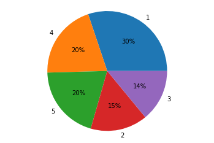

```python
percent_pie_chart(df, 'note')
```

**Observation des variables catégorielles**

```python
df.auteur.value_counts()
```

```
mikado-50419            4
mm-53953                4
pj-97010                4
tontonbubu-54321        4
lotus5-51217            3
                       ..
elya973-80260           1
jean-pierre-s-137446    1
sass-117513             1
marco14-138660          1
jesse-51459             1
Name: auteur, Length: 23675, dtype: int64
```

```python
df.assureur.unique()
```

```
array(['Direct Assurance', "L'olivier Assurance", 'Matmut',
       'Néoliane Santé', 'APRIL', 'SantéVet', 'Mercer', 'Generali',
       'Allianz', 'APRIL Moto', 'Cegema Assurances', 'LCL', 'Afer',
       'Pacifica', 'SwissLife', 'MAAF', 'Solly Azar', 'GMF', 'AMV',
       'CNP Assurances', 'MAIF', 'Sogecap', 'Harmonie Mutuelle',
       'Mutuelle des Motards', 'MACIF', 'Eurofil', 'Active Assurances',
       'AXA', 'Sogessur', 'Ag2r La Mondiale', 'Mgen', "Zen'Up", 'MGP',
       'Intériale', 'Génération', 'Cardif', 'Santiane', 'Eca Assurances',
       'Groupama', "Assur O'Poil", 'MMA', 'MetLife', 'Crédit Mutuel',
       'Afi Esca', 'Gan', 'Magnolia', 'Suravenir', 'Assur Bon Plan',
       'AssurOnline', 'Carac', 'Mapa', 'Malakoff Humanis',
       'Euro-Assurance', 'Peyrac Assurances', 'Sma', 'Hiscox'],
      dtype=object)
```

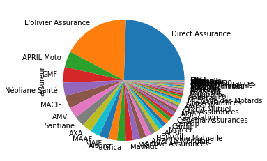

```python
df.assureur.value_counts().plot.pie()
```

Faisons un pie chart plus lissible.

```python
df.assureur.value_counts(normalize=True).sort_values(ascending=False)
```

```
Direct Assurance        0.244617
L'olivier Assurance     0.177903
APRIL Moto              0.042443
GMF                     0.041364
Néoliane Santé          0.035722
MACIF                   0.034394
AMV                     0.028544
Santiane                0.027300
AXA                     0.026096
MAAF                    0.025391
MAIF                    0.024520
Allianz                 0.023814
Pacifica                0.022943
Matmut                  0.019666
MGP                     0.018504
Active Assurances       0.016720
Ag2r La Mondiale        0.014521
Harmonie Mutuelle       0.012944
Eurofil                 0.011990
APRIL                   0.011741
Mercer                  0.011077
Cardif                  0.010994
Zen'Up                  0.010165
Cegema Assurances       0.008879
Génération              0.008796
Mgen                    0.008671
CNP Assurances          0.006099
Crédit Mutuel           0.006057
Afer                    0.005974
SwissLife               0.005725
Eca Assurances          0.005476
Mutuelle des Motards    0.005311
Generali                0.005311
Assur O'Poil            0.004564
Groupama                0.004024
Sogessur                0.003983
SantéVet                0.003983
Sogecap                 0.002987
Intériale               0.002572
MetLife                 0.002199
Assur Bon Plan          0.002116
Euro-Assurance          0.001784
Malakoff Humanis        0.001577
Gan                     0.001369
Carac                   0.001328
Peyrac Assurances       0.001162
Suravenir               0.001120
Afi Esca                0.001079
AssurOnline             0.001037
Solly Azar              0.001037
Magnolia                0.000788
LCL                     0.000747
Mapa                    0.000415
Sma                     0.000249
MMA                     0.000166
Hiscox                  0.000041
Name: assureur, dtype: float64
```

```python
df.assureur.value_counts(normalize=True).loc[lambda x: x>0.02].index
```

```
Index(['Direct Assurance', 'L'olivier Assurance', 'APRIL Moto', 'GMF',
       'Néoliane Santé', 'MACIF', 'AMV', 'Santiane', 'AXA', 'MAAF', 'MAIF',
       'Allianz', 'Pacifica'],
      dtype='object')
```

```python
def filter_percent_threshold(df, variable, threshold):
    df_ = df.copy()
    counts = df_[variable].value_counts(normalize=True)
    idx = counts[counts.lt(threshold)].index

    df_.loc[df_[variable].isin(idx), variable] = 'Autres'
    return df_
```

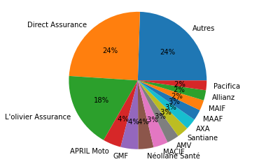

```python
df_plot = filter_percent_threshold(df, 'assureur', 0.02)
percent_pie_chart(df_plot, 'assureur')
```

```python
df.produit.unique()
```

```
array(['auto', 'sante', 'animaux', 'vie', 'moto', 'credit', 'habitation',
       'prevoyance', 'responsabilite-civile-professionnelle',
       'multirisque-professionnelle', 'assurances-professionnelles',
       'garantie-decennale', 'flotte-automobile'], dtype=object)
```

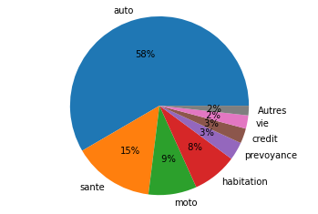

```python
df_plot = filter_percent_threshold(df, 'produit', 0.02)
percent_pie_chart(df_plot, 'produit')
```

## Analyse variable-target

```python
from wordcloud import WordCloud, ImageColorGenerator
import matplotlib.pyplot as plt
from PIL import Image
```

```python
!pip install wordcloud
```

```python
df.avis
```

```
0        Meilleurs assurances, prix, solutions, écoute,...
1        je suis globalement satisfait , sauf que vous ...
2        Prix tres abordable plusieurs options s'offren...
3        je satisfait du service, une réponse très rapi...
4        Client depuis plus de 25 ans, très déçu de cet...
                               ...
24100    Assurance moto chez la mutuel des motards en F...
24101    Même les demandes les plus simples n'aboutisse...
24102    En décembre 2019, j'ai souscrit à un contrat C...
24103    Je suis assurer à la gmf depuis plus de 15 ans...
24104    Bonjour\r\nMon ami vient de se faire voler sa ...
Name: avis, Length: 24105, dtype: object
```

```python
wc = WordCloud(background_color="white")
```

```python
Text = ''.join([str(text) for _,text in df.avis.items()])
```

```python
wc.generate(Text)
```

```
<wordcloud.wordcloud.WordCloud at 0x7ff732ba0950>
```

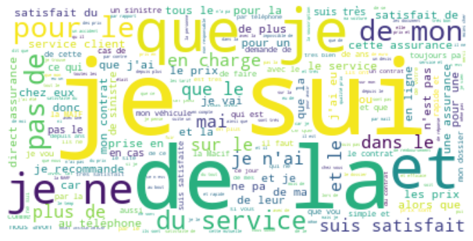

```python
plt.figure(figsize=(12,8))
plt.imshow(wc, interpolation='bilinear')
plt.axis("off")
plt.show()
```

### Produit:

```python
results = df.pivot_table(index='produit', columns='note',
                     aggfunc={"note":['count']})
results
```

| note produit | note count 1 | note count 2 | note count 3 | note count 4 | note count 5 |
| --- | --- | --- | --- | --- | --- |
| animaux | 223.0 | 70.0 | 33.0 | 21.0 | 27.0 |
| assurances-professionnelles | 6.0 | 2.0 | NaN | NaN | NaN |
| auto | 3021.0 | 2093.0 | 2158.0 | 3426.0 | 3378.0 |
| credit | 269.0 | 97.0 | 46.0 | 77.0 | 164.0 |
| flotte-automobile | 1.0 | NaN | NaN | NaN | NaN |
| garantie-decennale | 10.0 | NaN | NaN | 1.0 | 1.0 |
| habitation | 1073.0 | 534.0 | 195.0 | 95.0 | 59.0 |
| moto | 318.0 | 267.0 | 267.0 | 548.0 | 705.0 |
| multirisque-professionnelle | 8.0 | 1.0 | NaN | 8.0 | 3.0 |
| prevoyance | 522.0 | 119.0 | 80.0 | 34.0 | 35.0 |
| responsabilite-civile-professionnelle | 5.0 | NaN | NaN | NaN | NaN |
| sante | 1408.0 | 443.0 | 539.0 | 663.0 | 472.0 |
| vie | 407.0 | 90.0 | 63.0 | 12.0 | 6.0 |

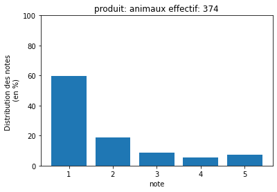

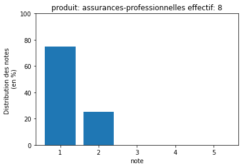

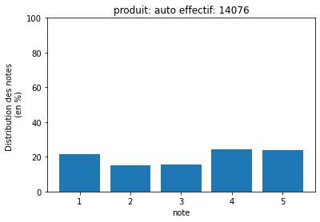

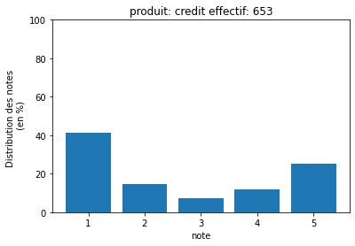

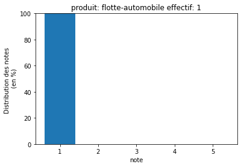

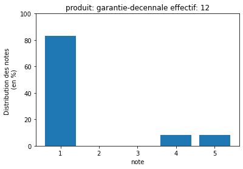

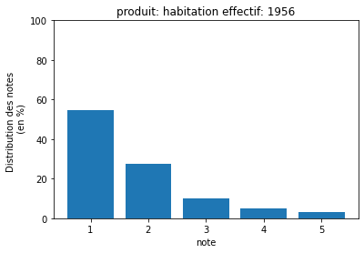

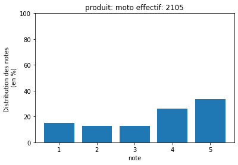

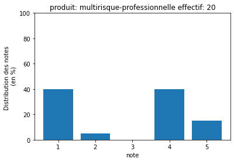

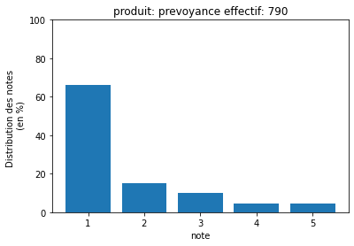

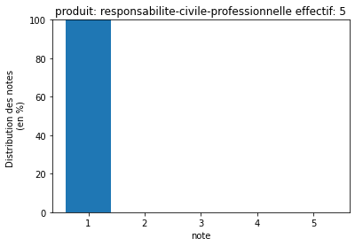

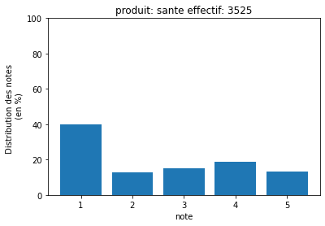

[1 more figures not shown]

```python
for produit in results.index:
    counts = pd.Series(results.loc[produit, :].values)
    counts = counts.fillna(0)
    eff = sum(counts)
    counts = 100*counts / eff

    fig, ax = plt.subplots()
    plt.bar(range(1,6), counts)
    ax.set_ylim(0,100)
    plt.title('produit: ' + produit + ' effectif: '+str(int(eff)))
    plt.ylabel('Distribution des notes \n (en %)')
    plt.xlabel('note')
    plt.show()
```

### Assureurs

```python
df_plot = df[df.assureur.isin(df.assureur.value_counts(normalize=True).loc[lambda x: x>0.02].index)]
results = df_plot.pivot_table(index='assureur', columns='note',
                     aggfunc={"note":['count']})
results
```

| note assureur | note count 1 | note count 2 | note count 3 | note count 4 | note count 5 |
| --- | --- | --- | --- | --- | --- |
| AMV | 74 | 86 | 80 | 186 | 262 |
| APRIL Moto | 56 | 70 | 152 | 340 | 405 |
| AXA | 363 | 143 | 86 | 22 | 15 |
| Allianz | 383 | 112 | 51 | 18 | 10 |
| Direct Assurance | 959 | 767 | 1111 | 1577 | 1482 |
| GMF | 215 | 220 | 180 | 227 | 155 |
| L'olivier Assurance | 383 | 332 | 530 | 1430 | 1613 |
| MAAF | 290 | 189 | 86 | 31 | 16 |
| MACIF | 423 | 250 | 81 | 43 | 32 |
| MAIF | 314 | 145 | 69 | 41 | 22 |
| Néoliane Santé | 267 | 106 | 166 | 180 | 142 |
| Pacifica | 289 | 122 | 56 | 63 | 23 |
| Santiane | 85 | 57 | 140 | 217 | 159 |

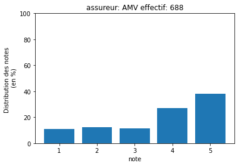

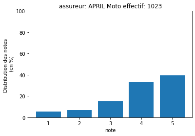

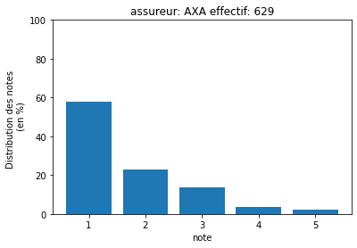

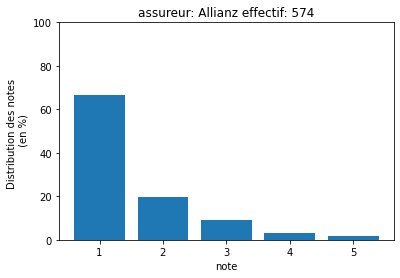

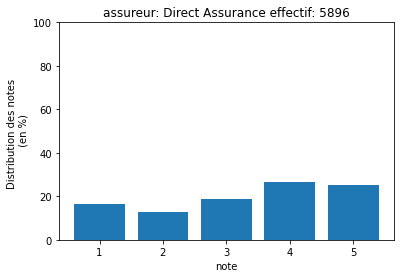

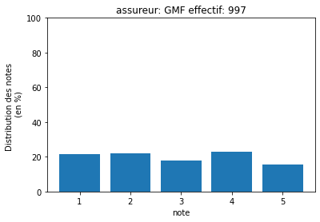

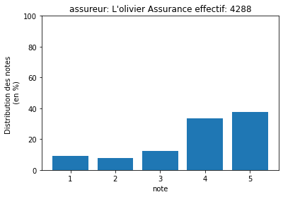

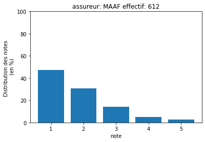

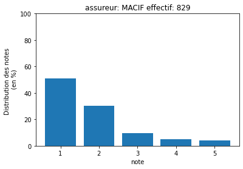

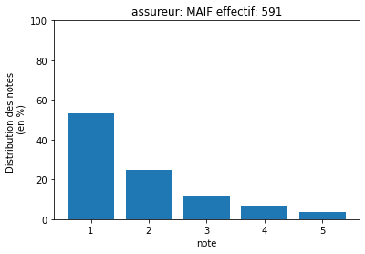

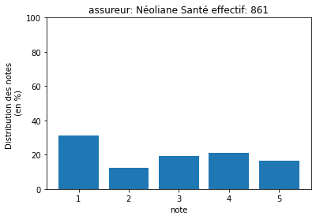

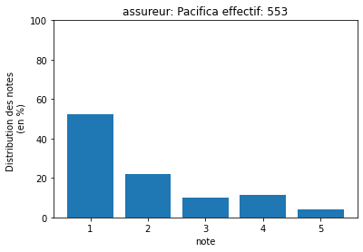

[1 more figures not shown]

```python
for assureur in results.index:
    counts = pd.Series(results.loc[assureur, :].values)
    counts = counts.fillna(0)
    eff = sum(counts)
    counts = 100*counts / eff

    fig, ax = plt.subplots()
    plt.bar(range(1,6), counts)
    ax.set_ylim(0,100)
    plt.title('assureur: ' + assureur + ' effectif: '+str(int(eff)))
    plt.ylabel('Distribution des notes \n (en %)')
    plt.xlabel('note')
    plt.show()
```

### Modèle

```python
from sklearn.metrics import mean_squared_error

from nltk.corpus import stopwords
from nltk import word_tokenize
from nltk.stem import SnowballStemmer
from sklearn.feature_extraction.text import TfidfVectorizer
import re

from sklearn.svm import LinearSVC
from sklearn.pipeline import Pipeline
from sklearn.model_selection import train_test_split
from sklearn.feature_selection import SelectKBest, chi2

from sklearn.preprocessing import StandardScaler, OneHotEncoder
```

```python
def netoyage_text_avis(A):
    # on enlève les stopwords et les carractères spéciaux
    B = [ i for i in  re.sub("[^a-zà-ÿ]", " ", str(A)).split() if i not in stop_words_list]
    #C = [ i.replace(',','') for i in B]
    # On récupère le radical de chaque mot
    C = [[fr.stem(word) for word in word_tokenize(B[i])][0] for i in range(len(B))]
    # On reconstitue la phrase
    D = ' '.join(C)
    return D
```

```python
stemmer = SnowballStemmer('french')
import nltk
nltk.download('stopwords')
stop_words_list = stopwords.words("french")
fr = SnowballStemmer('french')
```

```python
data_train['cleaned'] = data_train['avis'].apply(lambda x: netoyage_text_avis(x))

X_train, X_test, y_train, y_test = train_test_split(data_train['cleaned'], data_train.note, test_size=0.2)

pipeline = Pipeline([('vect', TfidfVectorizer(ngram_range=(1,1), stop_words=stop_words_list, sublinear_tf=True)),
                     ('chi',  SelectKBest(chi2, k=10000)),
                     ('clf', LinearSVC(C=1.0, penalty='l1', max_iter=3000, dual=False))])
```

```python
model = pipeline.fit(X_train, y_train)

vectorizer = model.named_steps['vect']
chi = model.named_steps['chi']
clf = model.named_steps['clf']

feature_names = vectorizer.get_feature_names()
feature_names = [feature_names[i] for i in chi.get_support(indices=True)]
feature_names = np.asarray(feature_names)

target_names = ['1', '2', '3', '4', '5']
print("top 10 keywords per class:")
for i, label in enumerate(target_names):
    top10 = np.argsort(clf.coef_[i])[-10:]
    print("%s: %s" % (label, " ".join(feature_names[top10])))

print("accuracy score: " + str(model.score(X_test, y_test)))
```

```
top 10 keywords per class:
1: ompte luis ridicul benghal quelquet déduis détach polo nce contactent
2: égarent abinet échapp traumatis sacrifi lex involontair tal thyroid aper
3: interviendr cheneau bobos lav plag alde ortugal élarg audienc enant
4: éger jesper fournitur sv felicit visualis expliquent périmetr chaton soupl
5: céler beurr luid poyr incompar conclur execut vot mme urofyl
accuracy score: 0.5042522298278366
```

## Recherche du meilleur parramètre TfidfVectorizer ngram_range

```python
Score = []
Parami = []

for i in range(1, 6):
    pipeline = Pipeline([
        ('vect', TfidfVectorizer(ngram_range=(1,i), stop_words=stop_words_list, sublinear_tf=True)),
        ('chi',  SelectKBest(chi2, k=10000)),
        ('clf', LinearSVC(C=1.0, penalty='l1', max_iter=3000, dual=False))
    ])
    model = pipeline.fit(X_train, y_train)
    y_pred = model.predict(X_test)
    RMSE = mean_squared_error(y_test, y_pred)
    Score.append(RMSE)
    Parami.append(i)
```

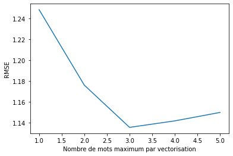

```python
plt.plot(Parami, Score)
plt.xlabel('Nombre de mots maximum par vectorisation')
plt.ylabel('RMSE')
```

### Prédiction :

```python
data_to_predict = pd.read_csv('avisassurance_test.csv', sep=';')

X = data_train['cleaned']
y = data_train.note

data_to_predict['cleaned'] = data_to_predict['avis'].apply(lambda x: netoyage_text_avis(x))

X_data_to_predict = data_to_predict['cleaned']

pipeline = Pipeline([('vect', TfidfVectorizer(ngram_range=(1,2), stop_words=stop_words_list, sublinear_tf=True)),
                     ('chi',  SelectKBest(chi2, k=10000)),
                     ('clf', LinearSVC(C=1.0, penalty='l1', max_iter=3000, dual=False))])
model = pipeline.fit(X, y) # On entraine le modèle sur l'ensemble des données de test
y_predict = model.predict(X_data_to_predict)
Data_to_save = data_to_predict.copy()
Data_to_save['note'] = y_predict
Data_to_save.to_csv('model1_predictions.csv', sep=';')
```

## Ajout des variables catégorielles au modèle.

```python
# Pipeline
from sklearn.pipeline import make_pipeline, Pipeline
from sklearn.compose import make_column_selector, make_column_transformer, ColumnTransformer
from sklearn.ensemble import RandomForestClassifier

from sklearn.gaussian_process import GaussianProcessClassifier
from sklearn.ensemble import AdaBoostClassifier
from sklearn.ensemble import GradientBoostingClassifier
from sklearn.metrics import classification_report
```

```python
avis_pipeline = Pipeline([
        ('vect', TfidfVectorizer(ngram_range=(1,2), stop_words=stop_words_list, sublinear_tf=True)),
        ('chi',  SelectKBest(chi2, k=10000)),
        ('clf', GradientBoostingClassifier(criterion='squared_error'))
    ])
categorical_pipeline = Pipeline(steps=[( 'onehot',OneHotEncoder(handle_unknown = 'ignore'))])
```

```python
preprocessor = ColumnTransformer(
transformers=[
                ('avis-pipeline', avis_pipeline, ['avis']),
                ('cat', categorical_pipeline, ['auteur', 'assureur', 'produit'])
])
```

```python
model = Pipeline(steps=[
        ('preprocessor', preprocessor),
        ('rfc', RandomForestClassifier())
    ])
```

```python
df = pd.read_csv('avisassurance_train.csv', sep=";")
data = df.copy().dropna(axis=0)
X = data.copy().drop(['note'], axis=1)
y = data.note.copy()
X_train, X_test, y_train, y_test = train_test_split(X, y, test_size=0.2)
```

```python
len(X), len(y)
```

```
(24103, 24103)
```

```python
len(X_train), len(y_train)
```

```
(19282, 19282)
```

```python
X_train.shape, y_train.shape
```

```
((19282, 5), (19282,))
```

```python
y_train = np.array(y_train)
```

```python
cat_features = ['auteur', 'assureur', 'produit']

cat_model = categorical_pipeline.fit(X_train[cat_features])
X_train_cat = cat_model.transform(X_train[cat_features])
X_train_cat
```

```
<19282x19081 sparse matrix of type '<class 'numpy.float64'>'
	with 57846 stored elements in Compressed Sparse Row format>
```

```python
nlp_model = avis_pipeline.fit(X_train['avis'], y_train)
X_train_avis_prob = nlp_model.predict_proba(X_train['avis'])
X_train_avis_prob
```

```
array([[0.03403386, 0.03305624, 0.10317184, 0.40216813, 0.42756993],
       [0.36341052, 0.21925767, 0.18674615, 0.13144566, 0.09913999],
       [0.46326553, 0.38019261, 0.08256055, 0.04034914, 0.03363216],
       ...,
       [0.05425919, 0.04649799, 0.29640994, 0.33895022, 0.26388265],
       [0.32466938, 0.24419712, 0.18745806, 0.15712396, 0.08655148],
       [0.48946832, 0.30578189, 0.10638948, 0.05598895, 0.04237135]])
```

```python
X_train_avis_prob.shape
```

```
(19282, 5)
```

```python
y_pred = nlp_model.predict(X_test['avis'])
```

```python
print(classification_report(y_test, y_pred))
print('RMSE : ',mean_squared_error(y_test, y_pred, squared=False))
```

```
              precision    recall  f1-score   support

           1       0.55      0.87      0.67      1426
           2       0.35      0.09      0.14       732
           3       0.34      0.11      0.16       658
           4       0.41      0.43      0.42       990
           5       0.51      0.57      0.54      1015

    accuracy                           0.49      4821
   macro avg       0.43      0.41      0.39      4821
weighted avg       0.45      0.49      0.44      4821

RMSE :  1.2346548249685365
```

```python
X_train_cat.toarray().shape
```

```
(19282, 19081)
```

```python
print(X_train_cat.shape)
print(X_train_avis_prob.shape)
A1 = np.array(X_train_avis_prob)
A2 = X_train_cat.toarray()
print(A1.shape, A2.shape)
X_merge_train = np.hstack((A1, A2))
X_merge_train
```

```
(19282, 19081)
(19282, 5)
(19282, 5) (19282, 19081)
```

```
array([[0.03403386, 0.03305624, 0.10317184, ..., 0.        , 0.        ,
        0.        ],
       [0.36341052, 0.21925767, 0.18674615, ..., 0.        , 1.        ,
        0.        ],
       [0.46326553, 0.38019261, 0.08256055, ..., 0.        , 1.        ,
        0.        ],
       ...,
       [0.05425919, 0.04649799, 0.29640994, ..., 0.        , 0.        ,
        0.        ],
       [0.32466938, 0.24419712, 0.18745806, ..., 0.        , 0.        ,
        0.        ],
       [0.48946832, 0.30578189, 0.10638948, ..., 0.        , 0.        ,
        0.        ]])
```

```python
X_test_avis_prob = nlp_model.predict_proba(X_test['avis'])
X_test_cat = cat_model.transform(X_test[cat_features])

print(X_train_cat.shape)
print(X_train_avis_prob.shape)
A1 = np.array(X_test_avis_prob)
A2 = X_test_cat.toarray()
print(A1.shape, A2.shape)
X_merge_test = np.hstack((A1, A2))
X_merge_test
```

```
(19282, 19081)
(19282, 5)
(4821, 5) (4821, 19081)
```

```
array([[0.04975827, 0.05980354, 0.14897091, ..., 0.        , 0.        ,
        0.        ],
       [0.02919449, 0.02468054, 0.11054581, ..., 0.        , 0.        ,
        0.        ],
       [0.0776624 , 0.06186106, 0.13881924, ..., 0.        , 0.        ,
        0.        ],
       ...,
       [0.20901816, 0.09429646, 0.12725754, ..., 0.        , 1.        ,
        0.        ],
       [0.55741833, 0.21425795, 0.10816404, ..., 0.        , 0.        ,
        0.        ],
       [0.30250555, 0.18429215, 0.20013908, ..., 0.        , 0.        ,
        0.        ]])
```

```python
X_merge_train.shape
```

```
(19282, 19086)
```

```python
from sklearn.preprocessing import MinMaxScaler
```

```python
scaler = MinMaxScaler()
sclaer = scaler.fit(X_merge_train)
X_merge_train_scaled = scaler.transform(X_merge_train)
X_merge_test_scaled = scaler.transform(X_merge_test)
```

```python
X_merge_train_scaled
```

```
array([[0.03089974, 0.03894753, 0.10571008, ..., 0.        , 0.        ,
        0.        ],
       [0.38036235, 0.2973646 , 0.20027852, ..., 0.        , 1.        ,
        0.        ],
       [0.4863067 , 0.52071592, 0.08238739, ..., 0.        , 1.        ,
        0.        ],
       ...,
       [0.05235845, 0.05760248, 0.32436849, ..., 0.        , 0.        ,
        0.        ],
       [0.33925872, 0.33197647, 0.20108408, ..., 0.        , 0.        ,
        0.        ],
       [0.51410737, 0.41744603, 0.109351  , ..., 0.        , 0.        ,
        0.        ]])
```

```python
model = Pipeline([
    ('chi',  SelectKBest(chi2, k=100)),
    ('lSVC',  LinearSVC())
])
model.fit(X_merge_train_scaled, y_train)
y_pred = model.predict(X_merge_test_scaled)
print(mean_squared_error(y_test, y_pred, squared=False))
```

```
1.0974126195654097
```

```python
from sklearn.metrics import accuracy_score
from sklearn.metrics import mean_squared_error
import xgboost as xgb

model=xgb.XGBRegressor()
model.fit(X_train,y_train)
y_pred=model.predict(X_test)
print("Accuracy: ", model.score(X_test,y_test))
print("MSE: ", mean_squared_error(y_pred,y_test))
print("RMSE: ", np.sqrt(mean_squared_error(y_pred,y_test)))
```

[output not shown]

## Recherche en vue de la création d'une autre pipline de preposessing pour la variable avis.

```python
!pip install --upgrade spacy
!python -m spacy download fr_core_news_sm
```

[output not shown]

```python
import spacy
# Load Our Model & NLP(TALN) Object
nlp = spacy.load('fr_core_news_sm')
```

```python
df = pd.read_csv('avisassurance_train.csv', sep=";")
```

```python
data = df.copy()
data = data.dropna(axis=0)
data
```

|  | date | note | auteur | avis | assureur | produit |
| --- | --- | --- | --- | --- | --- | --- |
| 0 | 06 septem... | 5 | brahim--k-131532 | Meilleurs assurances, prix, solutions, écoute,... | Direct Assurance | auto |
| 1 | 03 mai 20... | 4 | bernard-g-112497 | je suis globalement satisfait , sauf que vous ... | Direct Assurance | auto |
| 2 | 21 mars 2... | 5 | virginie-t-107352 | Prix tres abordable plusieurs options s'offren... | Direct Assurance | auto |
| 3 | 10 juin 2... | 4 | boulain-f-116580 | je satisfait du service, une réponse très rapi... | L'olivier Assurance | auto |
| 4 | 29 janvie... | 1 | ouaille31-51798 | Client depuis plus de 25 ans, très déçu de cet... | Matmut | auto |
| ... | ... | ... | ... | ... | ... | ... |
| 24100 | 22 mars 2... | 1 | hophop-107522 | Assurance moto chez la mutuel des motards en F... | Mutuelle des Motards | moto |
| 24101 | 06 décemb... | 1 | tzl-81680 | Même les demandes les plus simples n'aboutisse... | Allianz | habitation |
| 24102 | 14 avril ... | 1 | jmr-72500-110395 | En décembre 2019, j'ai souscrit à un contrat C... | Cegema Assurances | sante |
| 24103 | 11 juille... | 3 | cris-77532 | Je suis assurer à la gmf depuis plus de 15 ans... | GMF | auto |
| 24104 | 19 janvie... | 1 | jesse-51459 | Bonjour\r\nMon ami vient de se faire voler sa ... | AMV | moto |

24103 rows × 6 columns

```python
data['avis'][1]
```

```
"je suis globalement satisfait , sauf que vous avez un problème avec votre site internet ,impossible de déclarer un sinistre en ligne après plusieurs tentatives déclaration faite par téléphone ou tout c'est très bien passé , interlocutrice compétente et très agréable "
```

```python
doc = nlp(data['avis'][1])
type(doc)
```

```
spacy.tokens.doc.Doc
```

```python
for token in doc:
    if token.pos_ == 'ADJ':
        print(token)
```

```
globalement
satisfait
impossible
compétente
agréable
```

```python
from collections import Counter

def mots_les_plus_frequents_par_note(data, note):

  words = []
  avis = data.loc[lambda x: x['note']==note, 'avis']

  for i in range(len(avis)):
    doc = nlp(avis.iloc[i])
    # tous les tokens qui ne sont pas des stop words ou des mots de ponctuation
    words = words + [token.lemma_
          for token in doc
          if not token.is_stop and not token.is_punct]

  # Mots les plus fréquents
  word_freq = Counter(words)
  common_words = word_freq.most_common(20)
  return common_words

def adjectifs_les_plus_frequents_par_note(data, note):

  adjectifs = []
  avis = data.loc[lambda x: x['note']==note, 'avis']

  for i in range(len(avis)):

    doc = nlp(avis.iloc[i])
    # tous les tokens qui ne sont pas des stop words ou des mots de ponctuation
    adjectifs = adjectifs + [token.lemma_
          for token in doc
          if token.pos_ == "ADJ" and not token.is_stop and not token.is_punct]

  # Mots les plus fréquents
  word_freq = Counter(adjectifs)
  common_words = word_freq.most_common(20)
  return common_words
```

```python
mots_les_plus_frequents_par_note(data, 5)
```

```
[('\r\n', 3843),
 ('assurance', 2201),
 ('prix', 2125),
 ('service', 2057),
 ('satisfait', 1725),
 ('rapide', 1154),
 ('bon', 1116),
 (' ', 1063),
 ('bien', 1042),
 ('recommande', 974),
 ('tarif', 751),
 ('simple', 739),
 ('conseiller', 698),
 ('être', 672),
 ('contrat', 589),
 ('client', 550),
 ('satisfaire', 513),
 ('efficace', 466),
 ('écoute', 456),
 ('assurer', 446)]
```

```python
mots_les_plus_frequents_par_note(data, 4)
```

```
[('\r\n', 3784),
 ('prix', 1896),
 ('service', 1894),
 ('assurance', 1796),
 ('satisfait', 1488),
 ('bon', 1175),
 (' ', 1061),
 ('bien', 1055),
 ('rapide', 984),
 ('être', 754),
 ('contrat', 683),
 ('simple', 656),
 ('tarif', 650),
 ('conseiller', 607),
 ('client', 596),
 ('satisfaire', 567),
 ('recommande', 526),
 ('voir', 506),
 ('site', 475),
 ('efficace', 427)]
```

```python
mots_les_plus_frequents_par_note(data, 3)
```

```
[('\r\n', 2765),
 ('assurance', 1465),
 (' ', 1324),
 ('service', 990),
 ('prix', 965),
 ('contrat', 806),
 ('bien', 673),
 ('être', 644),
 ('faire', 574),
 ('satisfait', 562),
 ('client', 540),
 ('an', 516),
 ('sinistre', 484),
 ('bon', 476),
 ('véhicule', 452),
 ('mois', 415),
 ('tarif', 401),
 ('voir', 401),
 ('assurer', 397),
 ('cher', 379)]
```

```python
mots_les_plus_frequents_par_note(data, 2)
```

```
[('\r\n', 4274),
 ('assurance', 2239),
 (' ', 1826),
 ('être', 1292),
 ('contrat', 1290),
 ('sinistre', 1179),
 ('mois', 1114),
 ('faire', 1083),
 ('aucun', 1070),
 ('service', 1022),
 ('an', 1006),
 ('véhicule', 959),
 ('client', 903),
 ('bien', 808),
 ('assurer', 799),
 ('\r\n\r\n', 765),
 ('jour', 739),
 ('euro', 732),
 ('payer', 727),
 ('prendre', 717)]
```

```python
mots_les_plus_frequents_par_note(data, 1)
```

```
[('\r\n', 9168),
 ('assurance', 4663),
 (' ', 3961),
 ('contrat', 2992),
 ('mois', 2762),
 ('être', 2600),
 ('aucun', 2553),
 ('faire', 2271),
 ('an', 2181),
 ('service', 1973),
 ('sinistre', 1945),
 ('client', 1926),
 ('euro', 1842),
 ('payer', 1753),
 ('bien', 1715),
 ('rien', 1561),
 ('jour', 1522),
 ('dossier', 1522),
 ('prendre', 1510),
 ('\r\n\r\n', 1505)]
```

On remarque que les mots les plus fréquent pour les 2 meilleurs notes sont quasiments les mêmes.

```python
adjectifs_les_plus_frequents_par_note(data, 5)
```

```
[('satisfait', 1701),
 ('rapide', 1120),
 ('bon', 1082),
 ('simple', 601),
 ('efficace', 441),
 ('clair', 378),
 ('cher', 289),
 ('téléphonique', 277),
 ('agréable', 241),
 ('attractif', 236),
 ('direct', 234),
 ('intéressant', 228),
 ('compétitif', 213),
 ('professionnel', 203),
 ('correct', 191),
 ('réactif', 190),
 ('disponible', 145),
 ('aimable', 131),
 ('jeune', 131),
 ('meilleur', 125)]
```

```python
adjectifs_les_plus_frequents_par_note(data, 1)
```